# 11차 빅데이터 분석 II 및 시각화

## 프로젝트 개요

- 강의명 : (산대특)_공공데이터 활용 빅데이터 분석 및 시각화 전문가 과정 육성
- 교과목명 : 빅데이터 분석 II 및 시각화
- 프로젝트 주제 : tidymodels 라이브러리 및 Sale Price 데이터를 활용한 시각화 및 머신러닝 모델 개발
- 프로젝트 마감일 : 2022년 12월 19일
- 수강생명 : 황지훈

## 평가 1. 라이브러리 불러오기 (5점)

- 주요 라이브러리 및 설치 불러오는 코드를 작성한다.

```r
library(tidymodels)
```

## 평가 2. 데이터 불러오기 (5점)

- sale_price 데이터를 불러온다.
- head() 함수를 활용하여 데이터를 개괄적으로 보여주도록 한다.

```r
data("ames")
head(ames)
```

| MS_SubClass | MS_Zoning | Lot_Frontage | Lot_Area | Street | Alley | Lot_Shape | Land_Contour | Utilities | Lot_Config | Land_Slope | Neighborhood | Condition_1 | Condition_2 | Bldg_Type | House_Style | Overall_Cond | Year_Built | Year_Remod_Add | Roof_Style | Roof_Matl | Exterior_1st | Exterior_2nd | Mas_Vnr_Type | Mas_Vnr_Area | Exter_Cond | Foundation | Bsmt_Cond | Bsmt_Exposure | BsmtFin_Type_1 | … |
| --- | --- | --- | --- | --- | --- | --- | --- | --- | --- | --- | --- | --- | --- | --- | --- | --- | --- | --- | --- | --- | --- | --- | --- | --- | --- | --- | --- | --- | --- | --- |
| One_Story_1946_and_Newer_All_Styles | Residential_Low_Density | 141 | 31770 | Pave | No_Alley_Access | Slightly_Irregular | Lvl | AllPub | Corner | Gtl | North_Ames | Norm | Norm | OneFam | One_Story | Average | 1960 | 1960 | Hip | CompShg | BrkFace | Plywood | Stone | 112 | Typical | CBlock | Good | Gd | BLQ | … |
| One_Story_1946_and_Newer_All_Styles | Residential_High_Density | 80 | 11622 | Pave | No_Alley_Access | Regular | Lvl | AllPub | Inside | Gtl | North_Ames | Feedr | Norm | OneFam | One_Story | Above_Average | 1961 | 1961 | Gable | CompShg | VinylSd | VinylSd | None | 0 | Typical | CBlock | Typical | No | Rec | … |
| One_Story_1946_and_Newer_All_Styles | Residential_Low_Density | 81 | 14267 | Pave | No_Alley_Access | Slightly_Irregular | Lvl | AllPub | Corner | Gtl | North_Ames | Norm | Norm | OneFam | One_Story | Above_Average | 1958 | 1958 | Hip | CompShg | Wd Sdng | Wd Sdng | BrkFace | 108 | Typical | CBlock | Typical | No | ALQ | … |
| One_Story_1946_and_Newer_All_Styles | Residential_Low_Density | 93 | 11160 | Pave | No_Alley_Access | Regular | Lvl | AllPub | Corner | Gtl | North_Ames | Norm | Norm | OneFam | One_Story | Average | 1968 | 1968 | Hip | CompShg | BrkFace | BrkFace | None | 0 | Typical | CBlock | Typical | No | ALQ | … |
| Two_Story_1946_and_Newer | Residential_Low_Density | 74 | 13830 | Pave | No_Alley_Access | Slightly_Irregular | Lvl | AllPub | Inside | Gtl | Gilbert | Norm | Norm | OneFam | Two_Story | Average | 1997 | 1998 | Gable | CompShg | VinylSd | VinylSd | None | 0 | Typical | PConc | Typical | No | GLQ | … |
| Two_Story_1946_and_Newer | Residential_Low_Density | 78 | 9978 | Pave | No_Alley_Access | Slightly_Irregular | Lvl | AllPub | Inside | Gtl | Gilbert | Norm | Norm | OneFam | Two_Story | Above_Average | 1998 | 1998 | Gable | CompShg | VinylSd | VinylSd | BrkFace | 20 | Typical | PConc | Typical | No | GLQ | … |

## 평가 3. 데이터 시각화 (50점)

- 시각화 종류에 관계없이 시각화 10개를 작성한다.
- 평가기준
  - 10개 작성 : 50점
  - 7개 작성 : 35점
  - 5개 작성 : 25점
  - 3개 작성 : 15점
- 참고자료
  - URL : http://r-statistics.co/Complete-Ggplot2-Tutorial-Part1-With-R-Code.html

### (1) Scatter

- 리모델링년도별 가격 산점도 (1)
  - 리모델링건수가 증가 추세에 있다.

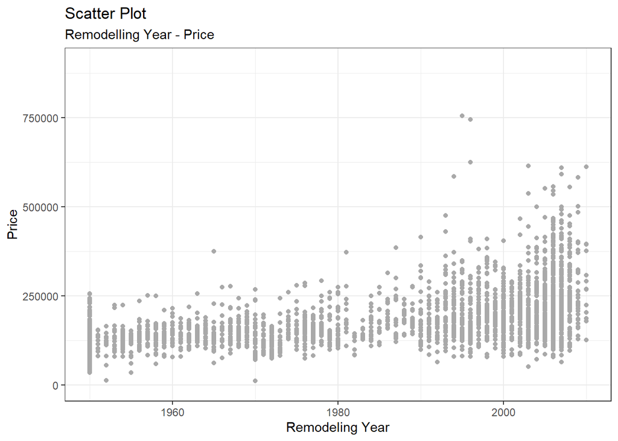

```r
ggplot(ames, aes(x=Year_Remod_Add, y=Sale_Price)) +
  geom_point(color = "darkgrey") +
  xlim(c(1950,2010)) +
  ylim(c(0,900000)) +
  labs(x = "Remodeling Year",
       y = "Price",
       title = "Scatter Plot",
       subtitle = "Remodelling Year - Price")+
  theme_bw()
```

- 리모델링년도별 가격 산점도 (2)
  - 주택 상태별로 표시하였지만, 밀도가 너무 좁아 전체적인 분포 파악이 어렵다.

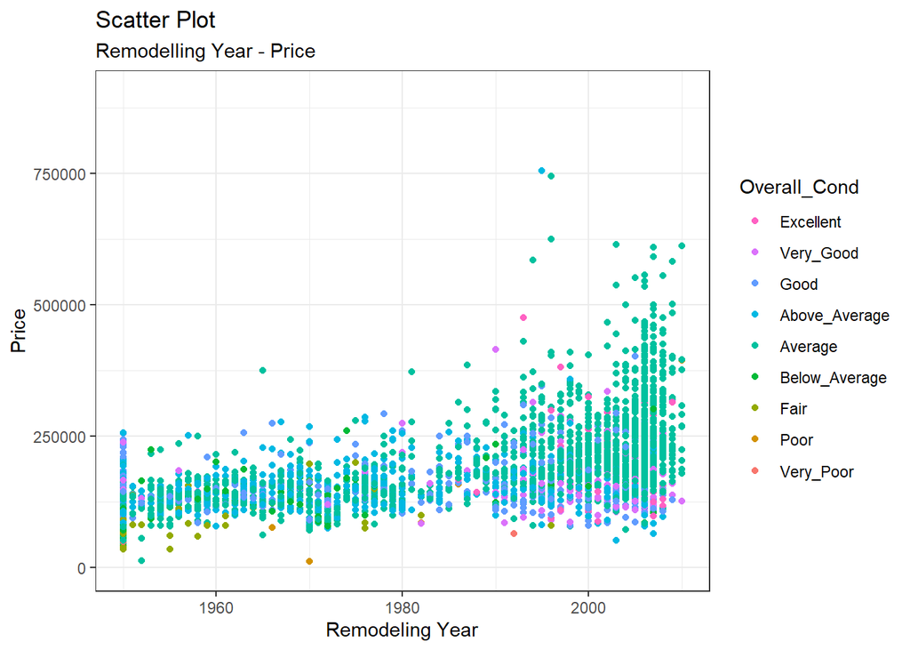

```r
ggplot(ames, aes(x=Year_Remod_Add, y=Sale_Price, color = Overall_Cond)) +
  geom_point() +
  xlim(c(1950,2010)) +
  ylim(c(0,900000)) +
  labs(x = "Remodeling Year",
       y = "Price",
       title = "Scatter Plot",
       subtitle = "Remodelling Year - Price")+
  theme_bw()+
  scale_color_discrete(breaks=c("Excellent","Very_Good","Good","Above_Average","Average","Below_Average","Fair","Poor","Very_Poor"))
```

### (2) Density

- 리모델링년도 별 밀도그래프 (1)
  - 주택품질 별 밀도그래프이다.
  - 품질이 좋은 주택의 분포가 상승추세이다.

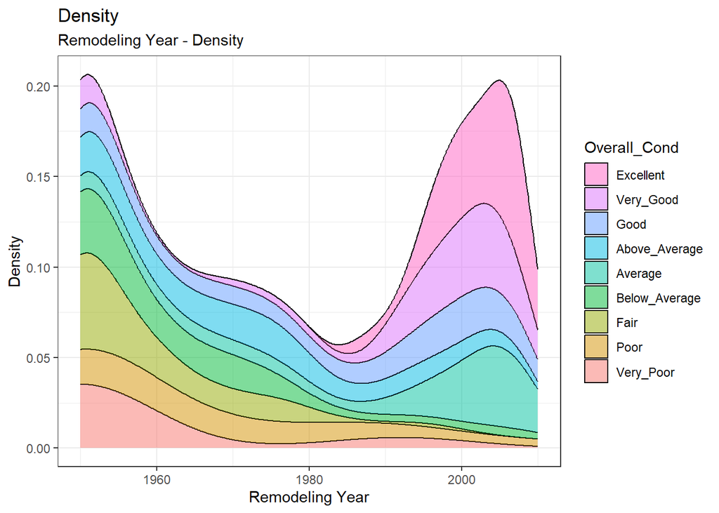

```r
ggplot(ames, aes(x = Year_Remod_Add,
                 fill = Overall_Cond))+
  geom_density(position = position_stack(reverse = TRUE),
               alpha=0.5)+
  xlim(c(1950,2010)) +
  labs(title="Density",
       subtitle = "Remodeling Year - Density",
       x = "Remodeling Year",
       y="Density")+
  theme_bw()+
  scale_fill_discrete(breaks=c("Excellent","Very_Good","Good","Above_Average","Average","Below_Average","Fair","Poor","Very_Poor"))
```

- 리모델링년도 별 밀도그래프 (2)
  - 난방품질 별 밀도그래프이다.
  - 최근들어 Excellent등급 난방품질의 밀도가 비교적 높다.
  - 1950년 이후로 Poor등급의 분포가 급락한것으로 보아, 향상된 난방기술의 보급이 이루어진듯 하다.

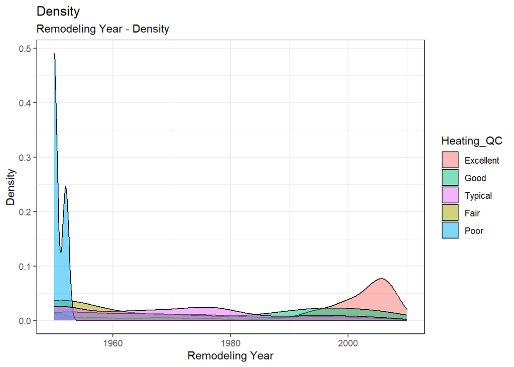

```r
ggplot(ames, aes(x = Year_Remod_Add,
                 fill = Heating_QC))+
  geom_density(alpha=0.5)+

  labs(title="Density",
       subtitle = "Remodeling Year - Density",
       x = "Remodeling Year",
       y="Density")+
  theme_bw()+
  scale_fill_discrete(breaks=c("Excellent","Good","Typical","Fair","Poor"))
```

### (3) Histogram

- 건축년도별 히스토그램 (1)
  - 건축 빈도가 증가 추세에 있다.

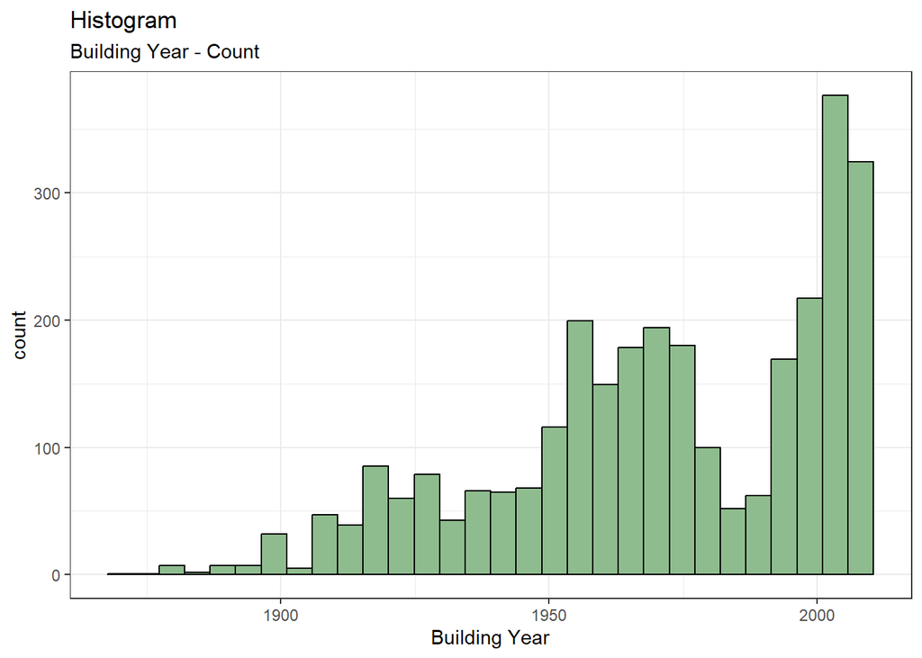

```r
ggplot(ames, aes(x = Year_Built))+
  geom_histogram(fill = "#8FBC8F",
                 colour="black",
                 bins=30)+
  labs(title="Histogram",
       subtitle = "Building Year - Count",
       x = "Building Year",
       y="count")+
  theme_bw()
```

- 건축년도별 히스토그램 (2)
  - 난방 품질 범례를 추가하였다.
  - 신축 건물일수록 난방 품질의 등급이 좋다.

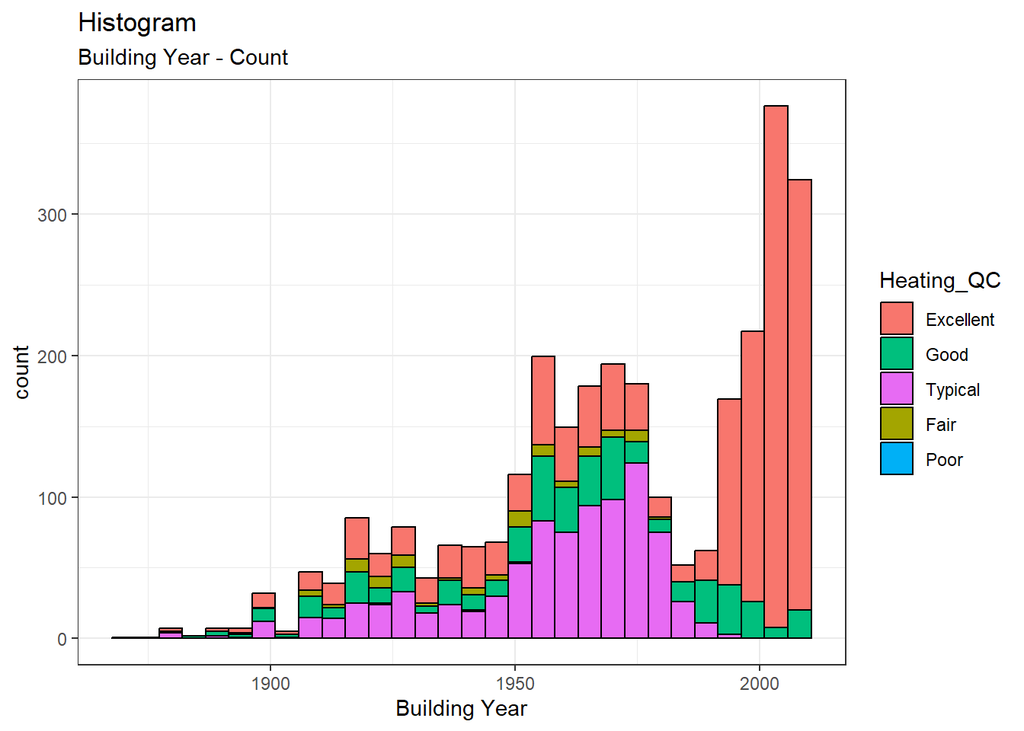

```r
ggplot(ames, aes(x = Year_Built,
                 fill = Heating_QC))+
  geom_histogram(colour="black",
                 bins=30)+
  labs(title="Histogram",
       subtitle = "Building Year - Count",
       x = "Building Year",
       y="count")+
  theme_bw()+
  scale_fill_discrete(breaks=c("Excellent","Good","Typical","Fair","Poor"))
```

### (4) Dot Plot

- 주택 상태별 가격 Dot Plot (1)
  - 산점도(2)에서 주택 상태별 가격 그래프를 좀 더 직관적으로 표시하였다.
  - 상태별로 가격분포의 전체적인 모양이 유사하다.

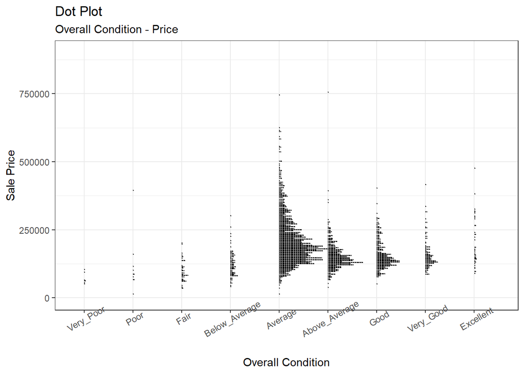

```r
ggplot(ames, aes(x = Overall_Cond,
                 y = Sale_Price))+
  geom_dotplot(binaxis = "y",
               binwidth = 3500)+
  labs(title="Dot Plot",
       subtitle = "Overall Condition - Price",
       x = "Overall Condition",
       y="Sale Price")+
  ylim(c(0,900000))+
  theme_bw()+
  theme(axis.text.x = element_text(angle=30))
```

- 주택 상태별 가격 Dot Plot (2)
  - 중앙배열형으로 시각화하였다.

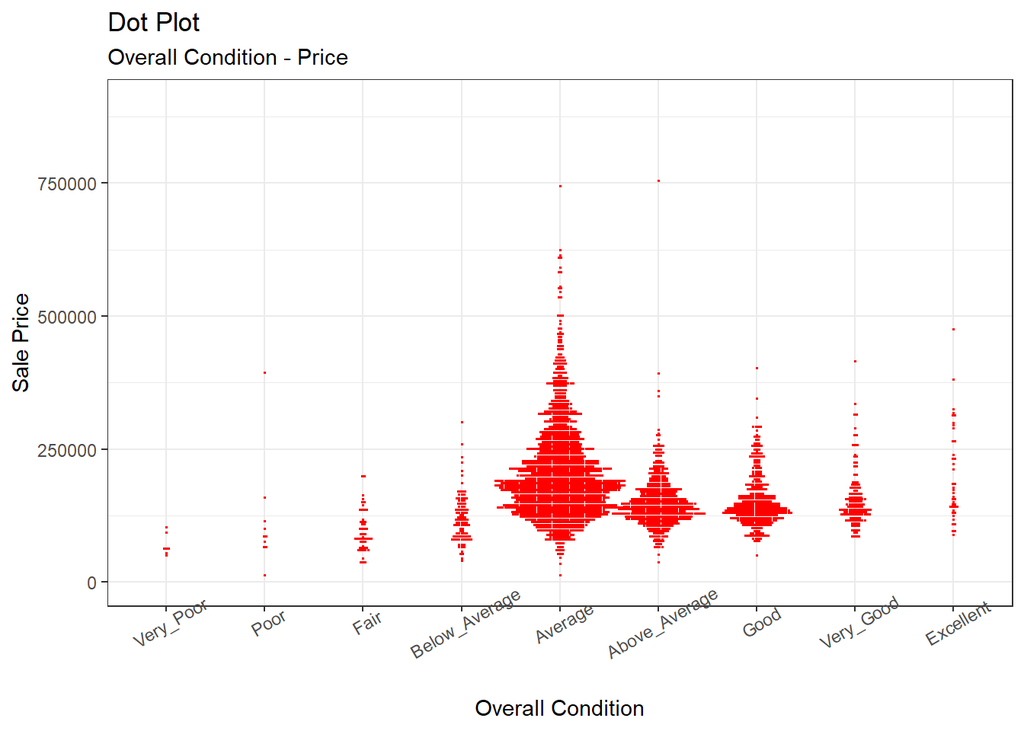

```r
ggplot(ames, aes(x = Overall_Cond,
                 y = Sale_Price))+
  geom_dotplot(binaxis = "y",
               binwidth = 4400,
               stackdir = "center",
               color="RED")+
  labs(title="Dot Plot",
       subtitle = "Overall Condition - Price",
       x = "Overall Condition",
       y="Sale Price")+
  ylim(c(0,900000))+
  theme_bw()+
  theme(axis.text.x = element_text(angle=30))
```

### (5) Bar Chart

- 중앙에어컨 막대그래프 (1)
  - 중앙에어컨 방식을 사용하는 주택이 압도적으로 많다.

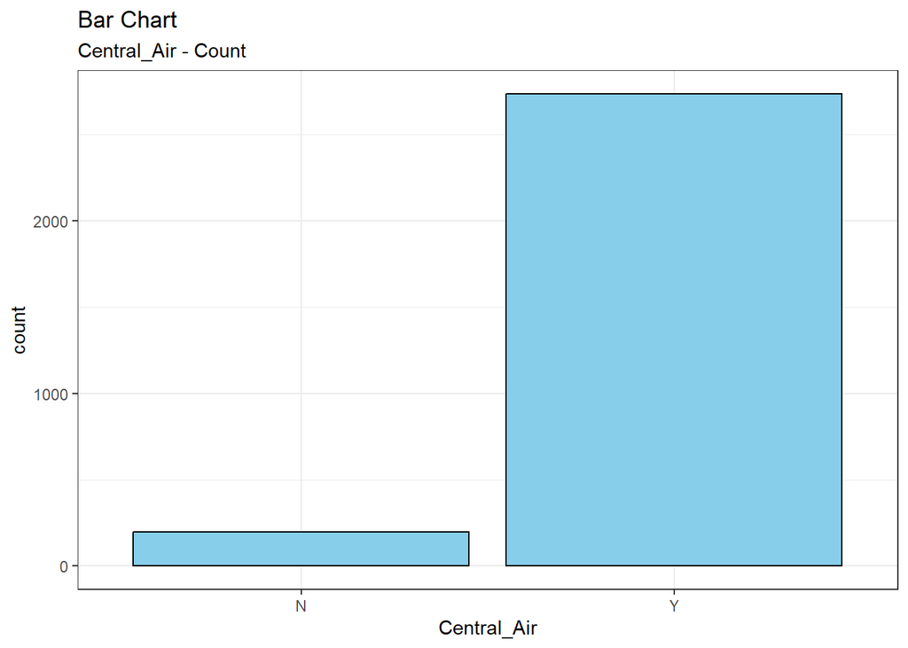

```r
ggplot(ames, aes(x = Central_Air))+
  geom_bar(stat="count",
           fill = "skyblue",
           colour="black")+
  labs(title="Bar Chart",
       subtitle = "Central_Air - Count",
       x = "Central_Air",
       y = "count")+
  theme_bw()
```

- 중앙에어컨 막대그래프(2)
  - 주택 품질별로 세분화하였다.

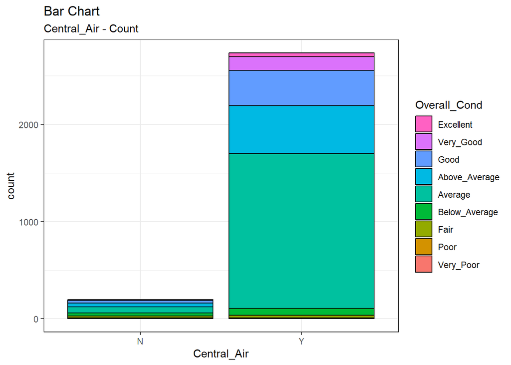

```r
ggplot(ames, aes(x = Central_Air,
                 fill = Overall_Cond))+
  geom_bar(stat="count",
           colour="black",
           position = position_stack(reverse = TRUE))+
  labs(title="Bar Chart",
       subtitle = "Central_Air - Count",
       x = "Central_Air",
       y = "count"
       )+
  theme_bw()+
  scale_fill_discrete(breaks=c("Excellent","Very_Good","Good","Above_Average","Average","Below_Average","Fair","Poor","Very_Poor"))
```

## 평가 4. 요약 통계 구하기 (10점)

- Sale_Price가 500000 이상인 데이터 중에서 Pool_QC에 따른 평균 Sale_Price 값을 구한다.

```r
ames %>%
  filter(Sale_Price>=500000) %>%
  group_by(Pool_QC) %>%
  summarise("Sale_Price (평균)" = mean(Sale_Price))
```

| Pool_QC | Sale_Price (평균) |
| --- | --- |
| Excellent | 680000.0 |
| No_Pool | 571524.1 |

## 평가 5. 머신러닝 모델링 (20점)

- 주어진 규칙에 따라 머신러닝 코드를 작성한다.
  - `8:2` 비율로 훈련데이터셋 및 테스트데이터셋으로 분리한다. (5점)
  - 모델링은 `RandomForest`와 `glmnet` 알고리즘을 활용한다. (10점)
    - 만약 1개만 사용 시 5점만 부여
  - feature Engineering 코드는 주어진 코드이기 때문에 그대로 활용한다.
- 옵션: 필요 시, 라이브러리 설치를 한다.
  - `install.packages(c('ranger', 'glmnet'))`
- Sale_Price와 각 모델의 예측 결과표를 만든다. (5점)

### (1) 훈련/테스트 데이터셋 만들기

- `8:2` 비율로 훈련데이터셋 및 테스트데이터셋으로 분리한다. (5점)

```r
set.seed(42)

data_split = initial_split(ames, strata = 'Sale_Price', prop = 0.8)

ames_train = training(data_split)
ames_test = testing(data_split)

x_features = recipe(
    Sale_Price ~ Garage_Area + Garage_Cond + Latitude + Lot_Area + Neighborhood + Year_Sold,
    data = ames_train
  ) %>%
  step_other(Neighborhood) %>%
  step_dummy(all_nominal()) %>%
  step_center(all_predictors()) %>%
  step_scale(all_predictors()) %>%
  step_log(Sale_Price, base = 10) %>%

  prep(training = ames_train, retain = TRUE)

data <- bake(x_features, new_data = ames_test, all_predictors())
```

### (2) RandomForest

- RandomForest 모형을 작성 후, 확인한다.

```r
rand_fit = rand_forest(mode = "regression", mtry = .preds(), trees = 1000) %>%
  set_engine("ranger") %>%
  fit(
    Sale_Price ~ ., data = bake(x_features, new_data = NULL)
  )

rand_fit
```

```
## parsnip model object
##
## Ranger result
##
## Call:
##  ranger::ranger(x = maybe_data_frame(x), y = y, mtry = min_cols(~.preds(),      x), num.trees = ~1000, num.threads = 1, verbose = FALSE,      seed = sample.int(10^5, 1))
##
## Type:                             Regression
## Number of trees:                  1000
## Sample size:                      2342
## Number of independent variables:  17
## Mtry:                             17
## Target node size:                 5
## Variable importance mode:         none
## Splitrule:                        variance
## OOB prediction error (MSE):       0.01065705
## R squared (OOB):                  0.6666121
```

### (3) glmnet

- glmnet 모형을 작성 후, 확인한다.

```r
glmn_fit = linear_reg(penalty = 0.001, mixture = 0.5) %>%
  set_engine("glmnet") %>%
  fit(Sale_Price ~ ., data = bake(x_features, new_data = NULL))

glmn_fit
```

```
## parsnip model object
##
##
## Call:  glmnet::glmnet(x = maybe_matrix(x), y = y, family = "gaussian",      alpha = ~0.5)
##
##    Df  %Dev   Lambda
## 1   0  0.00 0.233100
## 2   1  4.61 0.212400
## 3   1  8.85 0.193500
## 4   1 12.74 0.176300
## 5   1 16.28 0.160700
## 6   1 19.48 0.146400
## 7   1 22.37 0.133400
## 8   1 24.95 0.121500
## 9   1 27.25 0.110800
```

[output cut: 67 more lines]

### (4) 예측 결과표 만들기

- Sale_Price 컬럼과 예측 모델 결과표를 합한 새로운 데이터 프레임이다.

```r
data <- bake(x_features, new_data = ames_test, all_predictors())

test_results <- ames_test  %>%
  select(Sale_Price) %>%
  mutate(Sale_Price = log10(Sale_Price)) %>%
  bind_cols(
    predict(rand_fit, new_data = data) %>%
      rename(randomForest = .pred)
    , predict(glmn_fit, new_data = data) %>%
      rename(glmnet = .pred)
  )

test_results
```

| Sale_Price | randomForest | glmnet |
| --- | --- | --- |
| 5.021189 | 5.495981 | 5.282646 |
| 5.235528 | 5.150975 | 5.136429 |
| 5.595972 | 5.514369 | 5.405522 |
| 5.152288 | 5.112075 | 5.119199 |
| 5.264818 | 5.171704 | 5.187579 |
| 4.982271 | 5.060189 | 5.156617 |
| 5.023252 | 5.019125 | 5.177019 |
| 4.944483 | 5.029108 | 5.156414 |
| 5.175802 | 5.130472 | 5.221653 |
| 5.698970 | 5.554238 | 5.566395 |

[output cut: 578 more lines]

## 평가 6. 두개의 모형 비교 (10점)

- 회귀모형 평가지표를 활용하여 예측 지표를 작성한다. (5점)

```r
randomForest_results = test_results %>%
  metrics(truth = Sale_Price, estimate = randomForest) %>%
  mutate(model = 'randomForest')

glmnet_result = test_results %>%
  metrics(truth = Sale_Price, estimate = glmnet) %>%
  mutate(model = 'glmnet')

bind_rows(randomForest_results, glmnet_result)
```

| .metric | .estimator | .estimate | model |
| --- | --- | --- | --- |
| rmse | standard | 0.09340934 | randomForest |
| rsq | standard | 0.70528089 | randomForest |
| mae | standard | 0.06941215 | randomForest |
| rmse | standard | 0.10961728 | glmnet |
| rsq | standard | 0.58334495 | glmnet |
| mae | standard | 0.08356870 | glmnet |

- 두개의 그래프를 비교하는 코드를 작성한다. (5점)

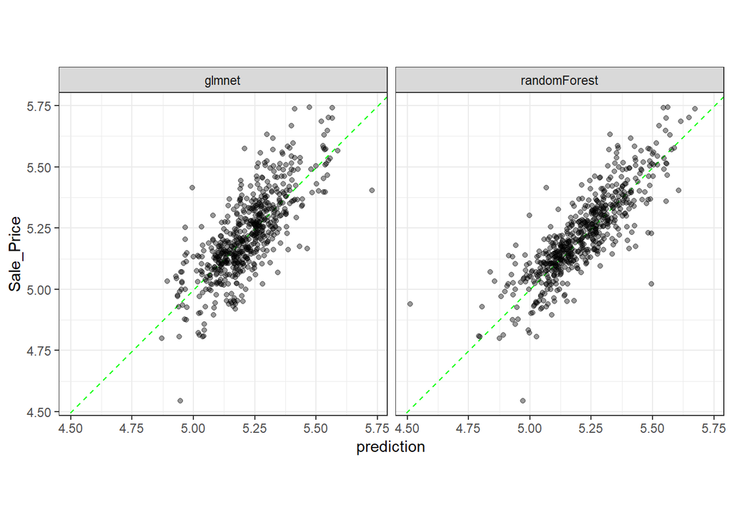

```r
test_results %>%
  gather(model, prediction, -Sale_Price) %>%
  ggplot(aes(x = prediction, y = Sale_Price)) +
  geom_abline(col = "green", lty = 2) +
  geom_point(alpha = .4) +
  facet_wrap(~model) +
  coord_fixed() +
  theme_bw()
```